# Découverte du jeu de données du projet SIWIM

```
##
Read 65.2% of 183928 rows
Read 183928 rows and 47 (of 47) columns from 0.042 GB file in 00:00:03
```

```
##  [1] "W1"  "W2"  "W3"  "W4"  "W5"  "W6"  "W7"  "W8"  "W9"  "W10" "W11"
## [12] "W12" "W13" "W14" "W15" "W16"
```

# Description des données

Chaque ligne représente les valeurs des variables pour un camion capturé par le système de pesage par poids du Pont de Normandie.

Il est important de rappeler que le système comporte sa propre fiabilité et est possiblement amené à capturer du bruit ou à dysfonctionner.

Nous notons ici la présence de nombreuses valeur manquantes ou de valeur aberrantes lorsque nous analysons par exemple les minimum ou les maximum de certaines variables.

# Analyse unidimensionnelle des variables qualitatives

# Analyse unidimensionnelle des variables quantitatives

la médiane du nombre d’essieux est 5. On observe des valeurs aberrantes car on considère qu’un nombre d’essieux supérieur à 8 est anormal.

`Total_axle_dist` exprime la distance total entre les essieux les plus éloignés du camion. Elle donne une approximation de la taille (une taille minimale) du camion.

Nous constatons que de nombreuses valeur sont aberrantes car cette distance va jusqu’à 80 mètres :

En France, la longueur maximale autorisée est autour de 18.50 mètres, nous considérons donc qu’au-delà de 20 mètres la valeur est aberrante.

Nous constatons des valeurs clairement aberrantes, toutes situées à -273 degrés.

La vitesse mediane est autour de 70km/h. Plusieurs vitesses apparaissent excessives (peut on rouler a plus de 130 km/h avec un camion ?).

Les derniers tracteurs de Volvo le peuvent. Mais nous pensons plutôt que ceux-ci ne fréquentent pas le pont de Normandie où la vitesse est de plus limitée à 90 km/h et que les camions chargés ont du mal à monter la pente. Nous devrons donc corriger ces valeurs aberrantes.

La Mediane du poids a 19 tonnes. Plusieurs valeurs semblent aberrantes (des camions de plus cent tonnes ou des camions avec un poids de 0 tonnes).

La limite légale étant à 44 tonnes et des poids lourds peuvent être surchargés, mais à partir de 70 tonnes il est sûr que les essieux ne tiennent pas la charge. Nous considérerons cette limite pour traiter les valeurs aberrantes.

Ces valeurs manquantes devront être traitées.

# Quelques graphiques

```r
# creation de jeux de données pour affichages graphiques

# Jeu de données des variables quantitatives
var_quali_graph <- varquali[,c("Lane", "Nb_axles", "Annee","Mois_annee","Jour_semaine","Heure","Anomalie")]

# Jeu de données des variables qualitatives
var_quanti_graph <- varquanti[,c("N","total_axle_dist","T","Reduced_chi_squared","Time_num","Vitesse","MGV")]

# Jeu de données globales, simplifiées, avant traitement des valeurs manquantes
var_graph <- cbind.data.frame(var_quali_graph,var_quanti_graph)
```

## Descripteurs des camions (variables quantitatives)

```r
# Histogramme

p1 <- ggplot(var_quanti_graph,aes(x = N)) +
  geom_histogram(color="black",fill= "lightblue",binwidth=1) +
  labs(title = "Essieux", x ="Nombre d'essieux", y ="Nombre de camions") +
  geom_vline(aes(xintercept=mean(N)),color="blue", linetype="dashed", size=1)+
  background_grid(major = "xy", minor = "none")

# Vitesse
p2 <- ggplot(var_quanti_graph,aes(x = Vitesse)) +
  geom_histogram(color="black",fill= "lightblue",binwidth=1) +
  labs(title = "Vitesse", x ="Vitesse (km/h)", y ="Nombre de camions") +
  geom_vline(aes(xintercept=mean(Vitesse)),color="blue", linetype="dashed", size=1) +
  background_grid(major = "xy", minor = "none")

# Masse du camion
p3 <- ggplot(var_quanti_graph,aes(x = MGV)) +
  geom_histogram(color="black",fill= "lightblue",binwidth=1) +
  labs(title = "Masse du camion", x ="Masse (tonnes)", y ="Nombre de camions") +
  geom_vline(aes(xintercept=mean(MGV)),color="blue", linetype="dashed", size=1) +
  background_grid(major = "xy", minor = "none")

# Distance maximale entre les essieux
p4 <- ggplot(var_quanti_graph,aes(x = total_axle_dist)) +
  geom_histogram(color="black",fill= "lightblue",binwidth=1) +
  labs(title = "Distance entre essieux", x ="Distance (m)", y ="Nombre de camions") +
  geom_vline(aes(xintercept=mean(total_axle_dist)),color="blue", linetype="dashed", size=1) +
  background_grid(major = "xy", minor = "none")

# Temperature du systeme de pesage
p5 <- ggplot(var_quanti_graph,aes(x = T)) +
  geom_histogram(color="black",fill= "lightblue",binwidth=1) +
  labs(title = "Température du systeme", x ="Temperature (°C)", y ="Nombre de camions") +
  geom_vline(aes(xintercept=mean(T)),color="blue", linetype="dashed", size=1) +
  background_grid(major = "xy", minor = "none")

# Chi2 reduit
p6 <- ggplot(var_quanti_graph,aes(x = Reduced_chi_squared)) +
  geom_histogram(color="black",fill= "lightblue",binwidth=1) +
  labs(title = "Chi2 reduit", x ="Chi2", y ="Nombre de camions") +
  geom_vline(aes(xintercept=mean(Reduced_chi_squared)),color="blue", linetype="dashed", size=1) +
  background_grid(major = "xy", minor = "none")
```

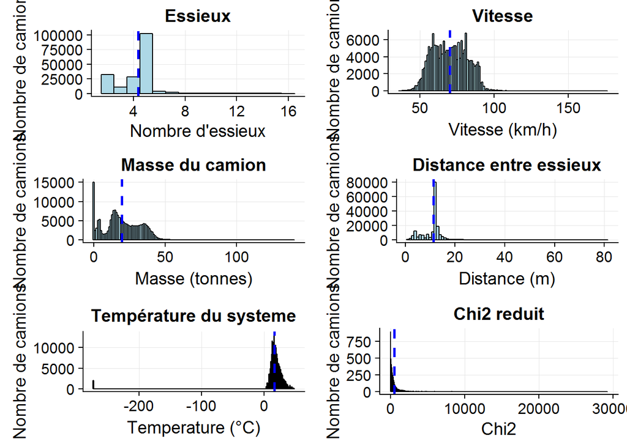

```r
plot_grid(p1,p2,p3,p4,p5,p6, ncol = 2, nrow = 3)
```

## Graphique valeurs manquantes

Les données provenant d’un système de capteurs, nous avons observé quelques valeurs manquantes

```r
# graphiques des valeurs manquantes


# bar plot de la proportion de valeurs manquantes par variables
```

[output not shown]

# Traitement des valeurs manquantes et aberrantes

Deux types de valeurs doivent être retraitées :

- les valeurs **manquantes**, qui doivent soit être estimées, soit éliminées par suppression de l’enregistrement associé
- les valeurs **aberrantes**, qui doivent soit être corrigées, soit éliminées par suppression de l’enregistrement associé

Nous allons explorer ces deux approches, en construisant deux jeux de données. Le premier avec des valeurs estimées, le deuxième avec des valeurs supprimées.

On travaille sur le tableau simplifié des variables quantitatives.

**Idée générale** : attribuer aux données aberrantes (dont nous sommes surs qu’elles soient fausses) un valeur “NA” puis reconstituer leur valeur grasse aux techniques d’imputation du package `"missMDA"`.

Les seuils sont fixés à partir de la connaissance métier.

On prépare le jeu de donnees `siwim_data_imput` contenant seulement les variables utiles pour l’imputation :

L’imputation est réalisée par analyse factorielle des données multiples (FAMD) du package `Factominer`. Nous retenons l’information apportée par 7 axes factoriels :

Voici le résumé des données après imputation :

```
##      Lane              N        Nb_axles   Anomalie   total_axle_dist
##  droite:167810   Min.   :2.00   2: 33262   N:130647   Min.   : 0.9032
##  gauche: 16118   1st Qu.:4.00   3: 11024   Y: 53281   1st Qu.: 9.2046
##                  Median :5.00   4: 28886              Median :12.1618
##                  Mean   :4.24   5:104079              Mean   :10.6736
##                  3rd Qu.:5.00   6:  3914              3rd Qu.:12.4314
##                  Max.   :8.00   7:  1981              Max.   :21.8551
##                                 8:   782
##        T          Reduced_chi_squared    Time_num         Vitesse
##  Min.   : 2.747   Min.   :    0.0     Min.   :0.5138   Min.   : 36.05
##  1st Qu.:13.752   1st Qu.:  100.0     1st Qu.:0.5929   1st Qu.: 60.43
##  Median :17.845   Median :  250.6     Median :0.6908   Median : 69.88
##  Mean   :19.237   Mean   :  475.5     Mean   :0.7071   Mean   : 70.12
##  3rd Qu.:23.713   3rd Qu.:  524.5     3rd Qu.:0.8274   3rd Qu.: 79.28
##  Max.   :47.568   Max.   :29201.3     Max.   :0.9078   Max.   :127.12
##
##       MGV
##  Min.   :-9.354
##  1st Qu.:13.533
##  Median :20.112
##  Mean   :21.316
##  3rd Qu.:30.120
##  Max.   :83.377
##
```

On concatène les variables imputées avec les colonnes initiales

Voici le résumé du jeu de données final après imputation, en comparaison de celui obtenu initialement :

```
##      Lane              N            Nb_axles      Anomalie
##  droite:167810   Min.   :2.000   5      :102466   N:130647
##  gauche: 16118   1st Qu.:4.000   2      : 32323   Y: 53281
##                  Median :5.000   4      : 28596
##                  Mean   :4.241   3      : 11023
##                  3rd Qu.:5.000   6      :  3914
##                  Max.   :8.000   (Other):  2763
##                  NA's   :2843    NA's   :  2843
##  total_axle_dist        T          Reduced_chi_squared    Time_num
##  Min.   : 0.903   Min.   : 2.747   Min.   :    0.0     Min.   :0.5138
##  1st Qu.: 9.188   1st Qu.:13.700   1st Qu.:  100.0     1st Qu.:0.5929
##  Median :12.165   Median :17.777   Median :  250.6     Median :0.6908
##  Mean   :10.622   Mean   :19.153   Mean   :  475.5     Mean   :0.7071
##  3rd Qu.:12.425   3rd Qu.:23.490   3rd Qu.:  524.5     3rd Qu.:0.8274
##  Max.   :20.000   Max.   :47.568   Max.   :29201.3     Max.   :0.9078
##  NA's   :5102     NA's   :2014
##     Vitesse            MGV
##  Min.   : 36.05   Min.   : 0.005
##  1st Qu.: 60.43   1st Qu.:13.487
##  Median : 69.88   Median :19.910
##  Mean   : 70.11   Mean   :21.382
##  3rd Qu.: 79.28   3rd Qu.:30.711
##  Max.   :127.12   Max.   :68.991
##  NA's   :19       NA's   :14338
```

```
##      Lane              N        Nb_axles   Anomalie   total_axle_dist
##  droite:167810   Min.   :2.00   2: 33262   N:130647   Min.   : 0.9032
##  gauche: 16118   1st Qu.:4.00   3: 11024   Y: 53281   1st Qu.: 9.2046
##                  Median :5.00   4: 28886              Median :12.1618
##                  Mean   :4.24   5:104079              Mean   :10.6736
##                  3rd Qu.:5.00   6:  3914              3rd Qu.:12.4314
##                  Max.   :8.00   7:  1981              Max.   :21.8551
##                                 8:   782
##        T          Reduced_chi_squared    Time_num         Vitesse
##  Min.   : 2.747   Min.   :    0.0     Min.   :0.5138   Min.   : 36.05
##  1st Qu.:13.752   1st Qu.:  100.0     1st Qu.:0.5929   1st Qu.: 60.43
##  Median :17.845   Median :  250.6     Median :0.6908   Median : 69.88
##  Mean   :19.237   Mean   :  475.5     Mean   :0.7071   Mean   : 70.12
##  3rd Qu.:23.713   3rd Qu.:  524.5     3rd Qu.:0.8274   3rd Qu.: 79.28
##  Max.   :47.568   Max.   :29201.3     Max.   :0.9078   Max.   :127.12
##
##       MGV
##  Min.   :-9.354
##  1st Qu.:13.533
##  Median :20.112
##  Mean   :21.316
##  3rd Qu.:30.120
##  Max.   :83.377
##
```

L’imputation semble donner de bons résultats. Etant basée sur une méthode d’estimation, les valeurs imputées peuvent de nouveaux franchir les limites fixées. Nous pouvons soit les supprimer, soit imputer aux valeurs limites de manière à conserver la donnée et donc le plus d’information possible.

La deuxième approche consiste à éliminer les individus ayant des valeurs manquantes et / ou aberrantes.

Résumé des données sans ces valeurs aberrantes :

```
##      Lane              N            Nb_axles     Anomalie
##  droite:153040   Min.   :2.000   5      :97144   N:129225
##  gauche: 14227   1st Qu.:4.000   2      :30411   Y: 38042
##                  Median :5.000   4      :26895
##                  Mean   :4.203   3      : 9642
##                  3rd Qu.:5.000   6      : 2326
##                  Max.   :8.000   7      :  807
##                                  (Other):   42
##  total_axle_dist         T          Reduced_chi_squared    Time_num
##  Min.   : 0.9032   Min.   : 2.747   Min.   :    0.267   Min.   :0.5156
##  1st Qu.: 9.2015   1st Qu.:13.653   1st Qu.:   98.981   1st Qu.:0.5952
##  Median :12.1660   Median :17.705   Median :  243.367   Median :0.6929
##  Mean   :10.5977   Mean   :19.090   Mean   :  434.471   Mean   :0.7095
##  3rd Qu.:12.4160   3rd Qu.:23.400   3rd Qu.:  494.676   3rd Qu.:0.8288
##  Max.   :20.0000   Max.   :47.568   Max.   :15348.500   Max.   :0.9078
##
##     Vitesse            MGV
##  Min.   : 36.05   Min.   : 0.00965
##  1st Qu.: 60.43   1st Qu.:13.55673
##  Median : 69.55   Median :19.96891
##  Mean   : 69.88   Mean   :21.43055
##  3rd Qu.: 78.85   3rd Qu.:30.74939
##  Max.   :127.12   Max.   :68.49185
##
```

Nous constatons que les deux méthodes semblent aboutir à des résultats similaires : les résumés montrent que les valeur prises par les indicateurs de dispersion et de position restent semblables.

Nous stockons à présent nos trois jeux de données pour les prochaines analyses :